# Inferential Statistics Course A.Y. 21/22

Della Gatta Antonio

21/12/2021

## COFNIDENCE INTERVAL SECOND MID TERM

this dataset is from a study of serious suicide attempts over three years in a predominantly rural population in Shandong, China.

One of the thing that could be interesting to make a study on is to notice the difference in proportion of people that have and that have not been Hospitalized.

```r
#https://vincentarelbundock.github.io/Rdatasets/csv/dplyr/starwars.csv
#https://vincentarelbundock.github.io/Rdatasets/csv/AER/CigarettesB.csv
#data$passengerClass =as.factor(data$passengerClass)



data <- read.csv("https://vincentarelbundock.github.io/Rdatasets/csv/Stat2Data/SuicideChina.csv")



View(data)
```

95% Confidence Interval for two proportions

I have to build a 95% Interval estimate of the difference between the non-survived proportion of people hospitalized and the survivor proportion of people who have been Hospitalized. As a first step, I build a table of my data.

```r
data %>%
  tabyl(Hospitalised, Died) %>%
  adorn_percentages() %>%
  adorn_pct_formatting() %>%
  adorn_ns()
```

```
##  Hospitalised           no           yes
##            no  0.0%    (0) 100.0% (1018)
##           yes 84.7% (1315)  15.3%  (238)
```

After that our aim is to understand if the difference in proportion is statistical significant. To evaluate this, I can use an interval estimate.

The point estimate is not reliable so, by calculating the confidence interval, we can have a more wide range of value.

I can use a bootstrap distribution that, basically, is a technique of sampling with replacement in order to obtain a simulated population from which my sample could have been potentially drawn.

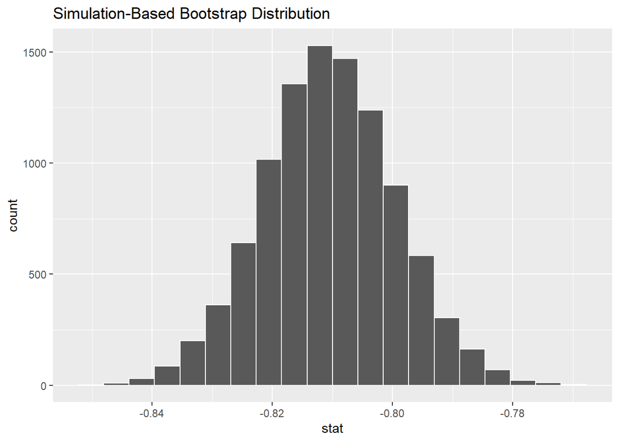

```r
set.seed(2020)
# I build the bootstrap distribution.

bootstrap_distribution <- data %>%
  specify(formula = Hospitalised~ Died, success = "yes") %>%
  generate(reps = 10000, type= "bootstrap") %>%
  calculate(stat = "diff in props", order = c("yes", "no"))

# visualize

bootstrap_distribution %>% visualise(bins=20)
```

Our distribution is basically normally distributed so we can proceed with both methods:

- percentile method

```r
# percentile method

percentile_ci_95=bootstrap_distribution %>%
  get_ci(level=0.95, type="percentile")

percentile_ci_95
```

```
## # A tibble: 1 x 2
##   lower_ci upper_ci
##      <dbl>    <dbl>
## 1   -0.832   -0.788
```

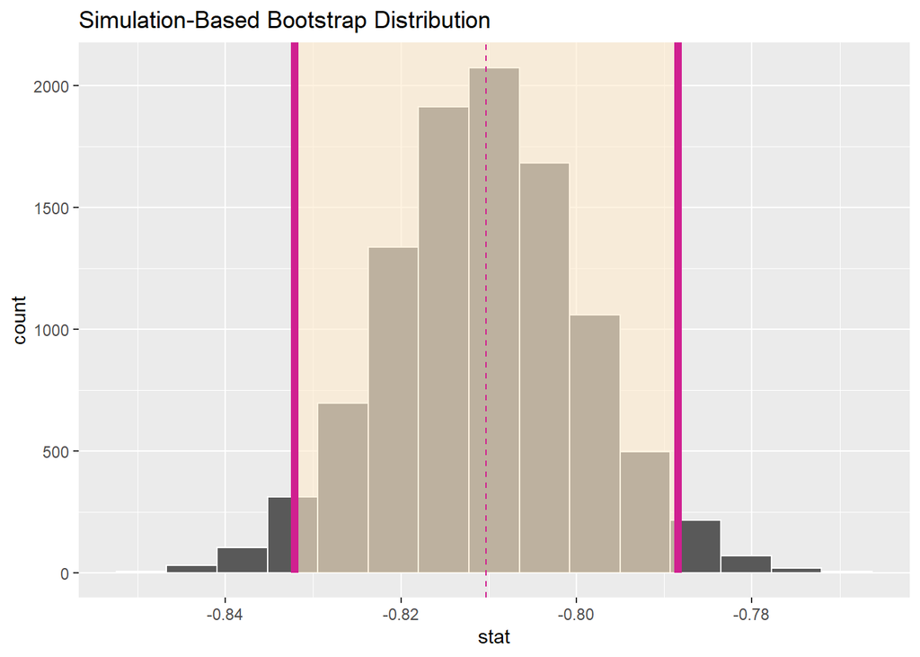

```r
# visualize the interval

visualize(bootstrap_distribution)+
  shade_confidence_interval(endpoints = percentile_ci_95 ,color = "violetred", fill = "blanchedalmond")+
  geom_vline(xintercept = (-0.8321626   -0.7884611)/2, linetype = "dashed", color="violetred")
```

Looking at the bootstrap distribution for the used estimator with a shaded confidence interval, we can state that most values (95% of them) lie between -0.8321626 and -0.7884611.

in different terms, if we constructed 100 confidence intervals for the same parameter with a confidence level of 95% we expect 95 of them to contain the true parameter.

- standard error

```r
# standard error method
## compute the observed statistic

obs_diff = data%>%
  specify(formula = Hospitalised~ Died, success = "yes") %>%
  calculate(stat = "diff in props", order = c("yes", "no"))

obs_diff
```

```
## Response: Hospitalised (factor)
## Explanatory: Died (factor)
## # A tibble: 1 x 1
##     stat
##    <dbl>
## 1 -0.811
```

```r
## compute endpoints

se_ci_95=bootstrap_distribution %>%
  get_ci(level=0.95, type="se", point_estimate = obs_diff) # in order to obtain the endpoints

se_ci_95
```

```
## # A tibble: 1 x 2
##   lower_ci upper_ci
##      <dbl>    <dbl>
## 1   -0.832   -0.789
```

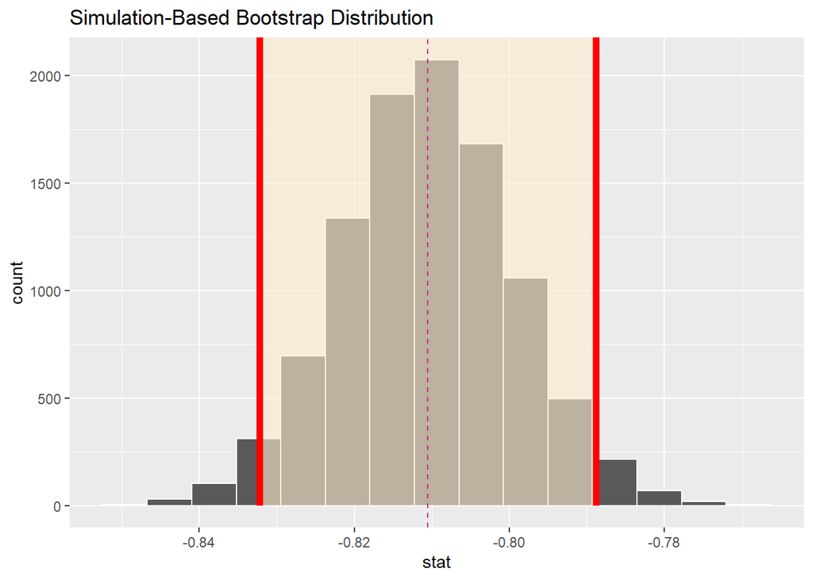

```r
## visualize the interval

visualize(bootstrap_distribution)+
  shade_confidence_interval(endpoints = se_ci_95 ,color = "red", fill = "blanchedalmond")+
  geom_vline(xintercept = (-0.8321979   -0.7888212  )/2 , linetype = "dashed", color="violetred")
```

## the difference between the two proportions is statistically significant

#let’s do the same process but with a confidence level of 90%

The 95% confidence interval has a greater margin of error than a 90% confidence interval computed on the same sample. This happens because if we have a greater confidence level, also the critical value is higher and this makes the interval wider This 95% confidence interval would have a smaller margin of error then the 90% confidence interval?

- percentile method

```r
percentile_ci_90=bootstrap_distribution %>%
  get_ci(level=0.90, type="percentile") # in order to obtain the endpoints

percentile_ci_90
```

```
## # A tibble: 1 x 2
##   lower_ci upper_ci
##      <dbl>    <dbl>
## 1   -0.829   -0.792
```

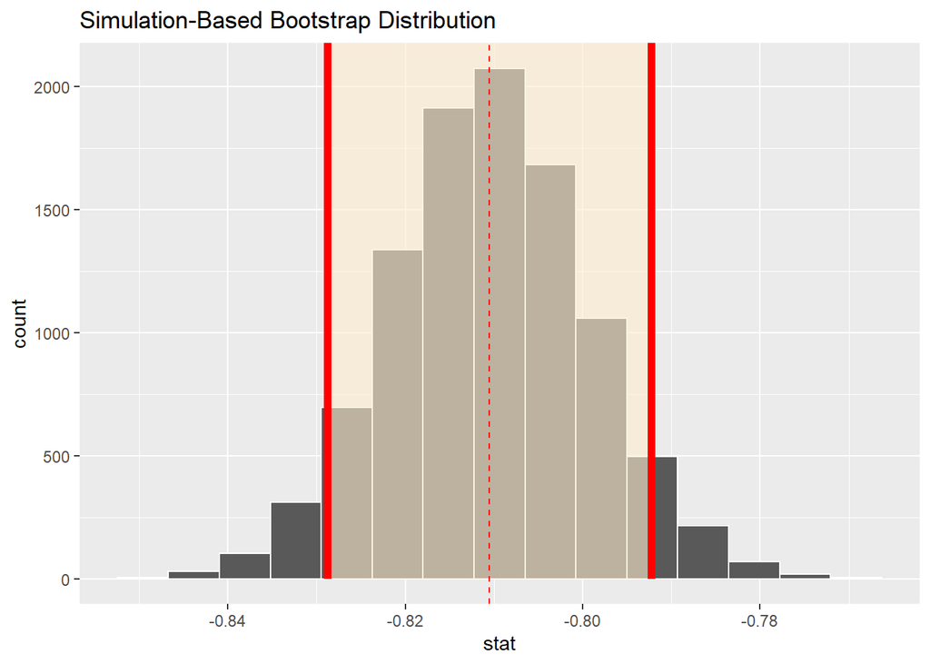

```r
visualize(bootstrap_distribution)+
  shade_confidence_interval(endpoints = percentile_ci_90 ,color = "red", fill = "blanchedalmond")+
   geom_vline(xintercept = (-0.8321979  -0.7888212  )/2, linetype = "dashed", color="red")
```

- standard error

```r
se_ci_90=bootstrap_distribution %>%
  get_ci(level=0.90, type="se", point_estimate = obs_diff) # in order to obtain the endpoints

se_ci_90
```

```
## # A tibble: 1 x 2
##   lower_ci upper_ci
##      <dbl>    <dbl>
## 1   -0.829   -0.792
```

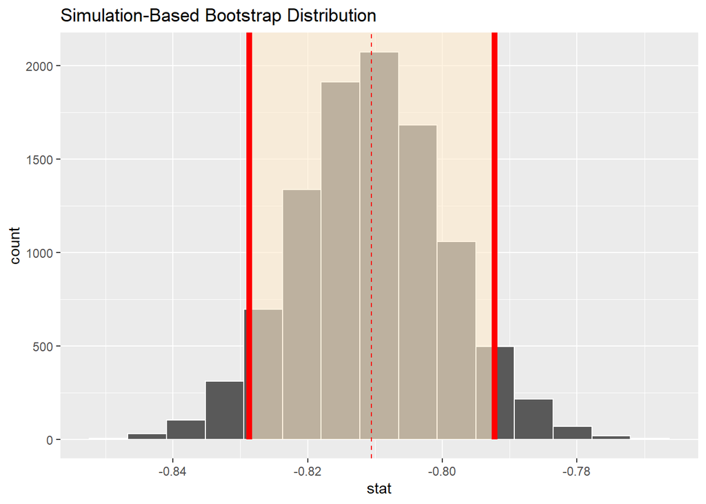

```r
visualize(bootstrap_distribution)+
  shade_confidence_interval(endpoints = se_ci_90 ,color = "red", fill = "blanchedalmond")+
   geom_vline( xintercept= (-0.8321979  -0.7888212  )/2, linetype = "dashed", color="red")
```

The interval has never contained “0” so itmo is statistically significant.

```r
a=se_ci_90$lower_ci
b=se_ci_90$upper_ci

EBM_90 = (b-a)/2
EBM_90
```

```
## [1] 0.01820144
```

I compute the error bound, considering the 95% confidence interval.

What is the error bound? it’s basically the range of value below and above the sample statistic.

```r
c = se_ci_95$upper_ci
d = se_ci_95$lower_ci

EBM_95 = (c-d)/2
EBM_95
```

```
## [1] 0.02168836
```

```r
EBM_95-EBM_90
```

```
## [1] 0.003486914
```

if we will have a large sample size the margin of error will decrease but if we have a 95% level of confidence that will not change!

also on a larger sample size we’ll have that 95% of them will have the right parameter.

## NOW LET’S TAKE A LOOK AT THE CONFIDENCE INTERVAL WITH MEAN’S DIFFERENCE

## **let’s use another dataset in order to see another aspect of the confidence interval**

The Star Wars API, or “swapi” (Swah-pee) is the world’s first quantified and programmatically-accessible data source for all the data from the Star Wars canon universe.

Here we can find a dataset from “swapi” with some descriptions and charateristics of the most important characters of the films.

We can find informations about the species, the homebirth, some physical charateristics and so on.

It could be interesting to see if the difference in mean of the height of masculine and the feminine is statistically significantly different from 0 with a confidence interval.

```r
data1 <- read.csv("https://vincentarelbundock.github.io/Rdatasets/csv/dplyr/starwars.csv")

#remove some NA values
data1<- data1[-c(28,37,40,80,82,83,84,85,86),]

View(data1)
```

The estimator to use is the sample statistic d_hat, the difference between the two sample means.

Let’s show a summary table of our data:

```r
summ_tab = data1 %>%
  group_by(gender) %>%
  summarise(sample_size = n(),
            mean = mean(`height`),
            std_dev = sd(`height`),
            minimum = min(`height`),
            q1 = quantile(`height`, 0.25),
            median = median(`height`),
            q3 = quantile(`height`, 0.75),
            maximum = max(`height`))
summ_tab
```

```
## # A tibble: 2 x 9
##   gender    sample_size  mean std_dev minimum    q1 median    q3 maximum
##   <chr>           <int> <dbl>   <dbl>   <int> <dbl>  <dbl> <dbl>   <int>
## 1 feminine           16  165.    23.6      96  162.   166.   172     213
## 2 masculine          62  177.    37.6      66  171.   183    193     264
```

Let’s plot a boxplot of the height for each gender.

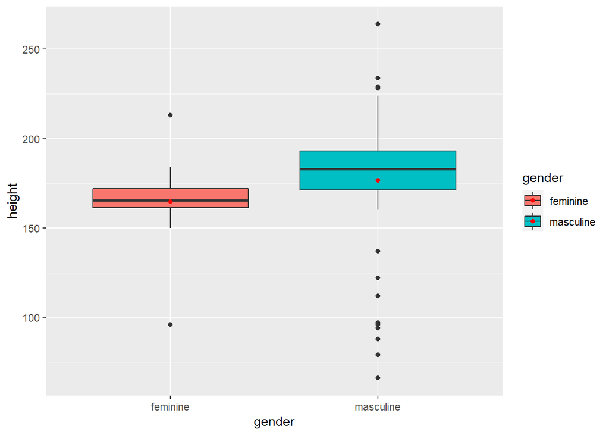

```r
data1 %>%
  ggplot(aes(x = gender, y = `height`, fill = gender)) +
  geom_boxplot() +
  stat_summary(fun = mean, geom = "point", color = "red")
```

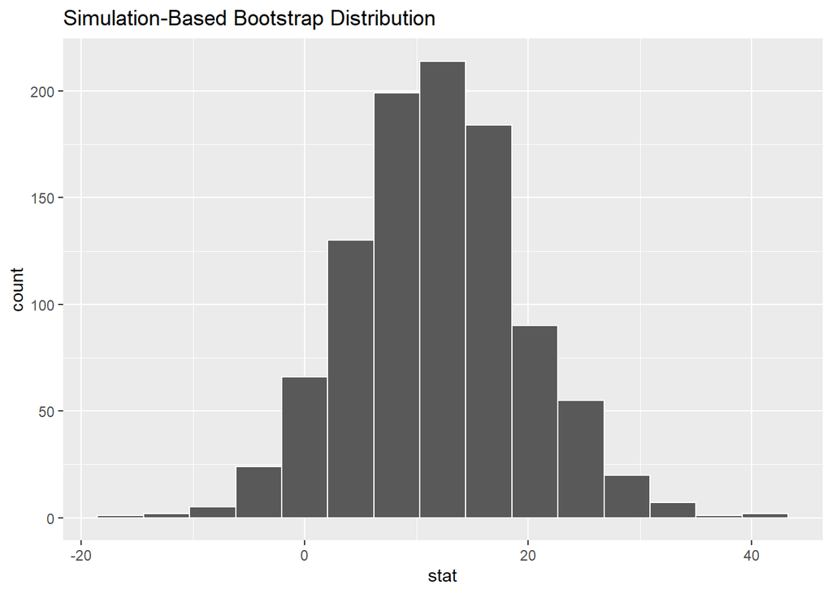

```r
set.seed(2021)
boot_dist = data1 %>%
  specify(formula = height ~ gender) %>%
  generate(reps = 1000, type = "bootstrap") %>%
  calculate(stat = "diff in means", order = c("masculine", "feminine"))

visualize(boot_dist)
```

```r
d_hat <- data1 %>%
  specify(height~ gender) %>%
  calculate(stat = "diff in means",
            order = c("masculine", "feminine"))
d_hat
```

```
## Response: height (numeric)
## Explanatory: gender (factor)
## # A tibble: 1 x 1
##    stat
##   <dbl>
## 1  11.8
```

# Bell-shaped distribution, so we can use both percentile and standard error method

we use the 99% level of confidences

Percentile method:

```r
percentile_ci <- boot_dist %>%
  get_confidence_interval(level = 0.99, type = "percentile")
percentile_ci
```

```
## # A tibble: 1 x 2
##   lower_ci upper_ci
##      <dbl>    <dbl>
## 1    -8.40     32.5
```

Visualize it:

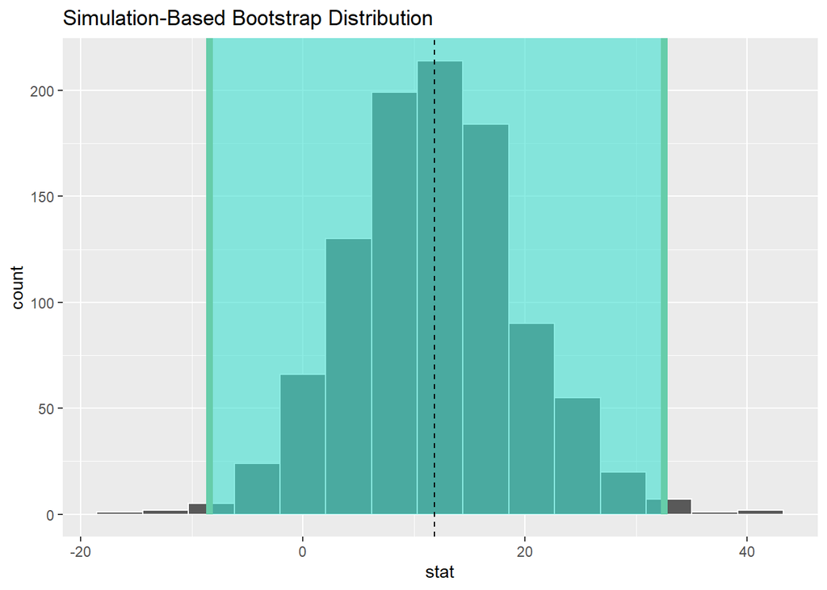

```r
visualize(boot_dist) +
  shade_confidence_interval(endpoints = percentile_ci)+
  geom_vline(xintercept = 11.82863  , linetype = "dashed")
```

SE method

```r
standard_error_ci <- boot_dist %>%
  get_confidence_interval(type = "se", point_estimate = d_hat)
```

```
## Using `level = 0.95` to compute confidence interval.
```

```r
standard_error_ci
```

```
## # A tibble: 1 x 2
##   lower_ci upper_ci
##      <dbl>    <dbl>
## 1    -3.29     26.9
```

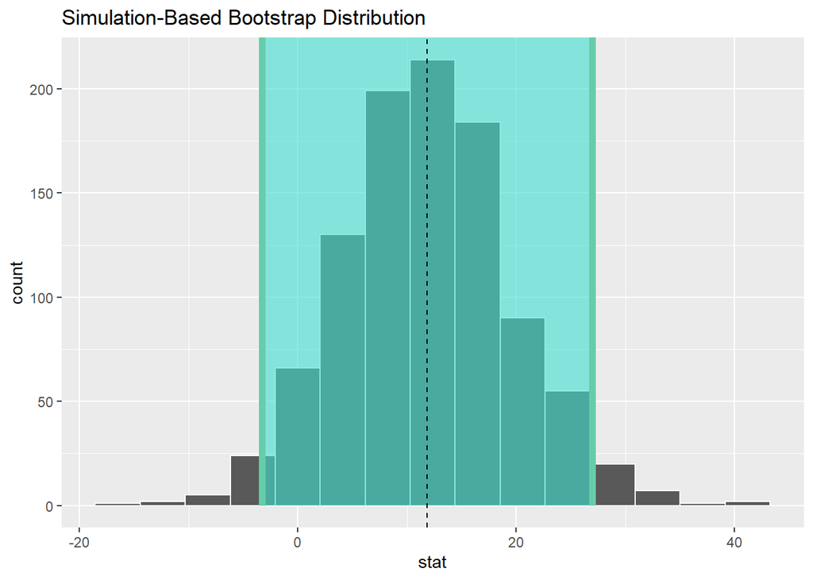

```r
visualize(boot_dist ) +
  shade_confidence_interval(endpoints = standard_error_ci)+
  geom_vline(xintercept = ((-3.28961    +26.94687)/2), linetype = "dashed")
```

## let’s do it with the 95% level of confidence

```r
data1 <- read.csv("https://vincentarelbundock.github.io/Rdatasets/csv/dplyr/starwars.csv")

#remove some NA values
data1<- data1[-c(28,37,40,80,82,83,84,85,86),]

d_hat <- data1 %>%
  specify(height ~ gender) %>%
  calculate(stat = "diff in means",
            order = c("masculine", "feminine"))
d_hat
```

```
## Response: height (numeric)
## Explanatory: gender (factor)
## # A tibble: 1 x 1
##    stat
##   <dbl>
## 1  11.8
```

compute the bootstrap distribution

```r
boot_distn_two_means <- data1 %>%
  specify(height ~ gender) %>%
  generate(reps = 10000, type = "bootstrap") %>%
  calculate(
    stat = "diff in means",
    order = c("masculine", "feminine")
  )
```

percentile method

```r
percentile_ci <- boot_distn_two_means %>%
  get_confidence_interval(level = 0.95, type = "percentile")
percentile_ci
```

```
## # A tibble: 1 x 2
##   lower_ci upper_ci
##      <dbl>    <dbl>
## 1    -2.75     27.2
```

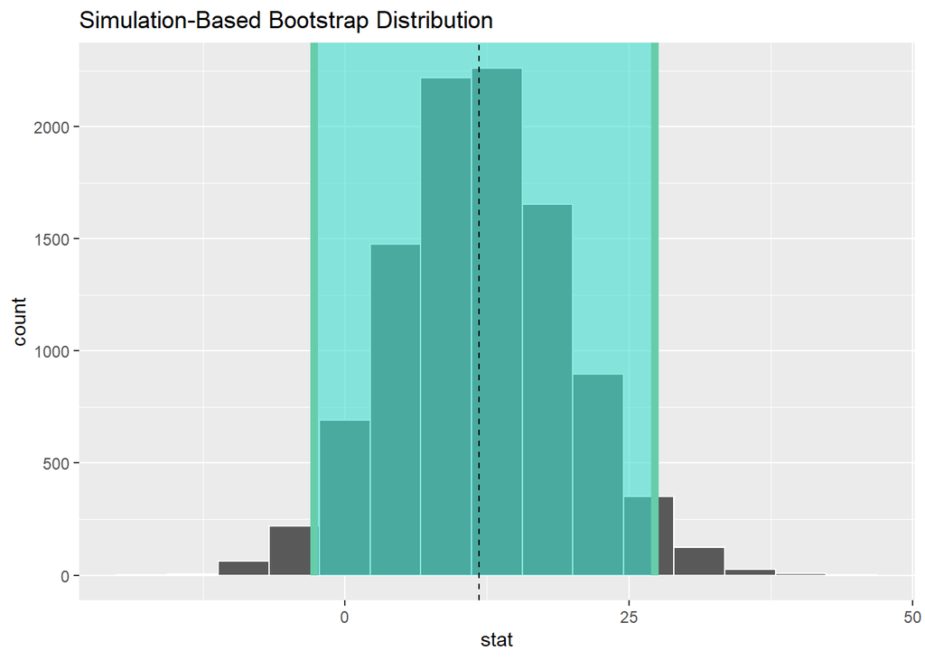

```r
visualize(boot_distn_two_means) +
  shade_confidence_interval(endpoints = percentile_ci)+
  geom_vline(xintercept = 11.82863  , linetype = "dashed")  #d_hat is 11.82863
```

SE method

```r
standard_error_ci <- boot_distn_two_means %>%
  get_confidence_interval(type = "se", point_estimate = d_hat)
```

```
## Using `level = 0.95` to compute confidence interval.
```

```r
standard_error_ci
```

```
## # A tibble: 1 x 2
##   lower_ci upper_ci
##      <dbl>    <dbl>
## 1    -3.10     26.8
```

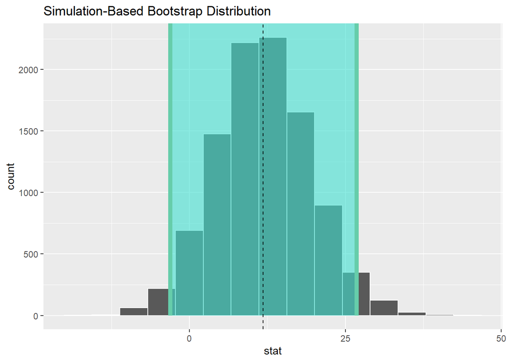

```r
visualize(boot_distn_two_means ) +
  shade_confidence_interval(endpoints = standard_error_ci)+
  geom_vline(xintercept = 11.82863  , linetype = "dashed")
```

```r
# larger sample size tend to produce narrower confidence interval.
```

Since the intervals obtained with both method contain the value 0 we can conclude that the difference in population means is not statistically significantly different from 0

the higher the confidence interval the higher the margin of error.

## Let’s image we want to construct a 68% confidence interval for the population parameter. What’s happen?

```r
se_ci_68 = boot_distn_two_means %>%
  get_ci(level = 0.68, type = "se", point_estimate = d_hat)
se_ci_68
```

```
## # A tibble: 1 x 2
##   lower_ci upper_ci
##      <dbl>    <dbl>
## 1     4.25     19.4
```

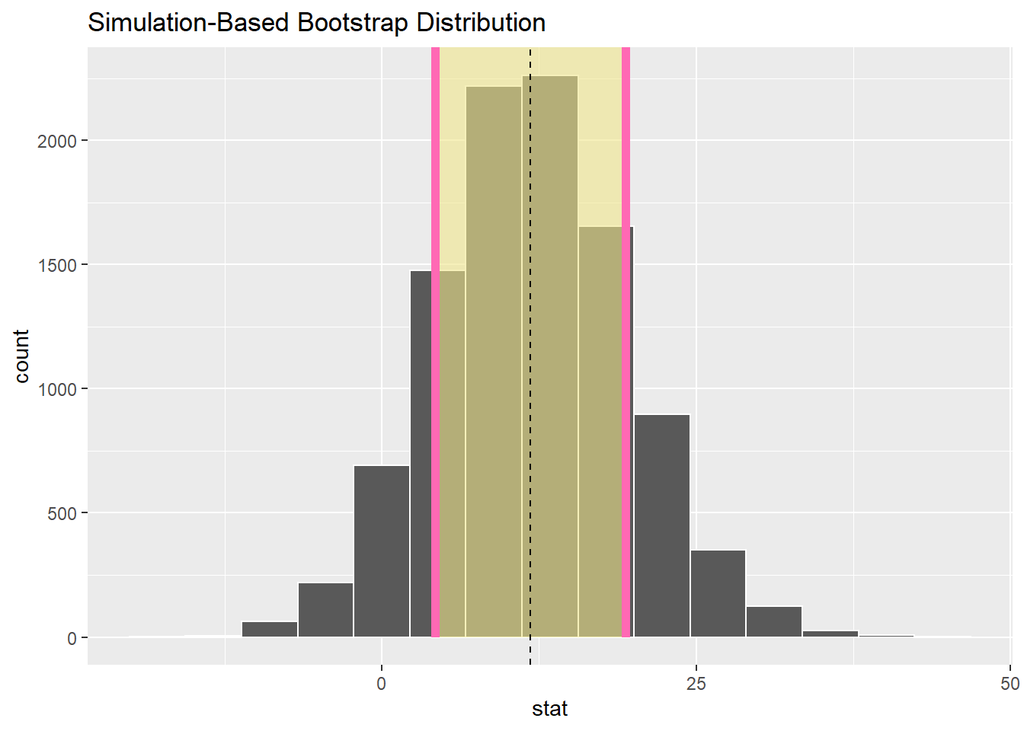

```r
boot_distn_two_means %>%

  visualise() +
  shade_ci(se_ci_68, color = "hotpink", fill = "khaki") +
  geom_vline(xintercept = 11.82863  ,linetype = "dashed")
```

This time the value “0” i s not contained in the interval it means that the confidence interval is significant.

But, in this case, we are less confident about our interval estimate.